# Female Participation in the Workforce

## *Summary Information Script:*

```r
library(dplyr)
library(tidyverse)
#List Containing Different Values from Data Set
summary_info <- list()

# 1 - Number of Observations
summary_info$number_observations <- nrow(summary_table_3)
summary_info$number_observations
```

```
## [1] 7344
```

```r
# 2 & 3 - Number of Unique Countries/Entities in Dataset
summary_info$list_of_countries <- unique(summary_table_3$Country)

summary_info$number_of_countries <- length(unique(summary_table_3$Country))
summary_info$number_of_countries
```

```
## [1] 272
```

```r
#4 & 5 - Highest/Lowest Unemployment Rate of Women
summary_info$highest_unemployment_rate_of_women <- summary_table_3 %>%
  filter(Unemployment_rate_women == max(Unemployment_rate_women, na.rm = TRUE)) %>%
  pull(Year,Country)
summary_info$highest_unemployment_rate_of_women
```

```
## Algeria
##    1996
```

```r
summary_info$lowest_unemployment_rate_of_women <- summary_table_3 %>%
  filter(Unemployment_rate_women == min(Unemployment_rate_women, na.rm = TRUE)) %>%
  pull(Year,Country)
summary_info$lowest_unemployment_rate_of_women
```

```
## Cambodia Cambodia
##     2014     2015
```

```r
# 6 & 7 -Highest/Lowest Long Run Perspective on Female Labor Force Participation Rates
summary_info$highest_long_run_perspective <- summary_table_3 %>%
  filter(long_run_perspective_female_labor_force_participation_rate ==
           max(long_run_perspective_female_labor_force_participation_rate,
               na.rm = TRUE)) %>%
  pull(Year, Country)
summary_info$highest_long_run_perspective
```

```
## Iceland
##    2016
```

```r
summary_info$lowest_long_run_perspective <- summary_table_3 %>%
  filter(long_run_perspective_female_labor_force_participation_rate ==
           min(long_run_perspective_female_labor_force_participation_rate,
               na.rm = TRUE)) %>%
  pull(Year, Country)
summary_info$lowest_long_run_perspective
```

```
## Turkey
##   2005
```

```r
#Summary Information List
View(summary_info)
```

## *Chart 1:*

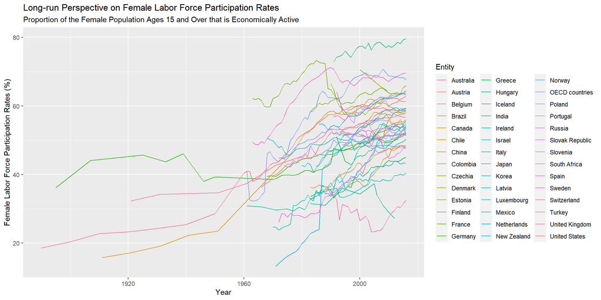

```r
chart1 <- ggplot() +
  geom_line(aes(y=long_run_perspective_female_labor_force_participation_rate, x=Year,group=Entity, color=Entity), data = long_run_perspective) +
  ggtitle("Long-run Perspective on Female Labor Force Participation Rates", subtitle= "Proportion of the Female Population Ages 15 and Over that is Economically Active") +
  xlab("Year") +
  ylab("Female Labor Force Participation Rates (%)")

chart1
```

### *Chart 1 Explanation:*

We chose to incorporate this graph into our research as we believe it accurately depicts the long-run perspective on female labor force participation rates over the course of the past 100 years. We chose to include many countries in this visualizaiton as we believe it encompasses broader trends across the world. One observation from the graph is that a majority of the data was compiled beginning in the 1960-70s, with very few countries having data that dates back prior to the 1920s. Another observation is that nearly every country has experienced rapid growth in the percentage of the female population, 15+, that is economically active compared to the growth rates in the earlier periods, such as 1920-1960.